# EDA

## Data Acquisition

To download the differents speaches we scrap the speaches on 2 differents websites. The speaches from Macron come from the website of the Embassy of France in Washington DC (USA) and regarding Boris Johnson speaches, it comes from the official website of the governement of the United-Kingdom.

### Emmanuel Macron

We choose the 3 first speaches from Macron about the corona virus dating from the: * 12 march (text1) * 16 march (text2) * 13 april (text3)

Macron’s speeches

| Text | Types | Tokens | Sentences |
| --- | --- | --- | --- |
| text1 | 1007 | 3772 | 162 |
| text2 | 917 | 2947 | 107 |
| text3 | 1103 | 3730 | 107 |

### Boris Johnson

Johnson’s speeches

| Text | Types | Tokens | Sentences |
| --- | --- | --- | --- |
| text1 | 266 | 577 | 21 |
| text2 | 409 | 1170 | 49 |
| text3 | 405 | 1165 | 42 |
| text4 | 406 | 1175 | 51 |
| text5 | 321 | 904 | 1 |
| text6 | 357 | 946 | 42 |
| text7 | 300 | 729 | 33 |

Johnson made more speeches but shorter. His first speech was 577 words, then the following ones ranged from 729 to 1175 words.

## Tokenisation, Lemmatization & Cleaning

The numbers, the punctuation,the symbols and the separators are remove. As well as unimportant words. Moreover we cast all letters to their lower option.

### Emmanuel Macron

```
## Tokens consisting of 3 documents.
## text1 :
##  [1] "man"        "woman"      "france"     "dear"       "compatriot"
##  [6] "past"       "week"       "country"    "confront"   "spread"
## [11] "virus"      "covid-19"
## [ ... and 1,718 more ]
##
## text2 :
##  [1] "woman"    "man"      "france"   "thursday" "night"    "speak"
##  [7] "health"   "crisis"   "country"  "confront" "point"    "epidemic"
## [ ... and 1,314 more ]
##
## text3 :
##  [1] "frenchwoman" "frenchman"   "dear"        "compatriot"  "live"
##  [6] "difficult"   "times.we"    "feel"        "fear"        "distress"
## [11] "right"       "now"
## [ ... and 1,690 more ]
```

### Boris Johnson

```
## Tokens consisting of 7 documents.
## text1 :
##  [1] "morning"      "chair"        "meet"         "government's" "cobr"
##  [6] "emergency"    "committee"    "coronavirus"  "outbreak"     "first"
## [11] "minister"     "scotland"
## [ ... and 246 more ]
##
## text2 :
##  [1] "good"         "afternoon"    "everybody"    "thank"        "much"
##  [6] "come"         "just"         "chair"        "meet"         "government's"
## [11] "emergency"    "committee"
## [ ... and 501 more ]
##
## text3 :
##  [1] "good"      "afternoon" "everybody" "thank"     "much"      "come"
##  [7] "want"      "bring"     "everyone"  "date"      "national"  "fight"
## [ ... and 477 more ]
##
## text4 :
##  [1] "good"      "afternoon" "thank"     "come"      "indeed"    "tune"
##  [7] "daily"     "update"    "want"      "introduce" "sure"      "know"
## [ ... and 532 more ]
##
## text5 :
##  [1] "want"     "begin"    "thank"    "everyone" "thank"    "medium"
##  [7] "also"     "thank"    "everyone" "huge"     "effort"   "country"
## [ ... and 356 more ]
##
## text6 :
##  [1] "good"       "afternoon"  "thank"      "come"       "today"
##  [6] "join"       "chancellor" "exchequer"  "rishi"      "sunak"
## [11] "jennie"     "harry"
## [ ... and 392 more ]
##
## [ reached max_ndoc ... 1 more document ]
```

## Document-Term Matrix DTM

Now let’s compute the word frequencies (TF) by documents. First, the tokens are grouped by the indicator Document, which allows to count the words by documents.

### Table

*Emmanuel Macron*

|  | document | term | count |
| --- | --- | --- | --- |
| 1 | 1 | ability | 4 |
| 2 | 1 | able | 10 |
| 3 | 1 | absolute | 2 |
| 4 | 1 | accelerate | 2 |
| 5 | 1 | accord | 1 |
| 6 | 1 | achieve | 1 |
| 7 | 1 | act | 1 |
| 8 | 1 | action | 5 |
| 9 | 1 | activity | 1 |
| 10 | 1 | acute | 1 |

[output cut: 2175 more lines]

*Boris Johnson*

|  | document | term | count |
| --- | --- | --- | --- |
| 1 | 1 | able | 1 |
| 2 | 1 | absolutely | 2 |
| 3 | 1 | across | 1 |
| 4 | 1 | action | 2 |
| 5 | 1 | advice | 3 |
| 6 | 1 | advisor | 2 |
| 7 | 1 | afraid | 1 |
| 8 | 1 | agree | 1 |
| 9 | 1 | ahead | 2 |
| 10 | 1 | also | 2 |

[output cut: 1622 more lines]

### Most frequent words

We only keep the 15 most frequent words for redability purpose and create barplots using ggplot and geom_col. The facetwrap function split the barplots per Document.

#### All text confused

*Emmanuel Macron*

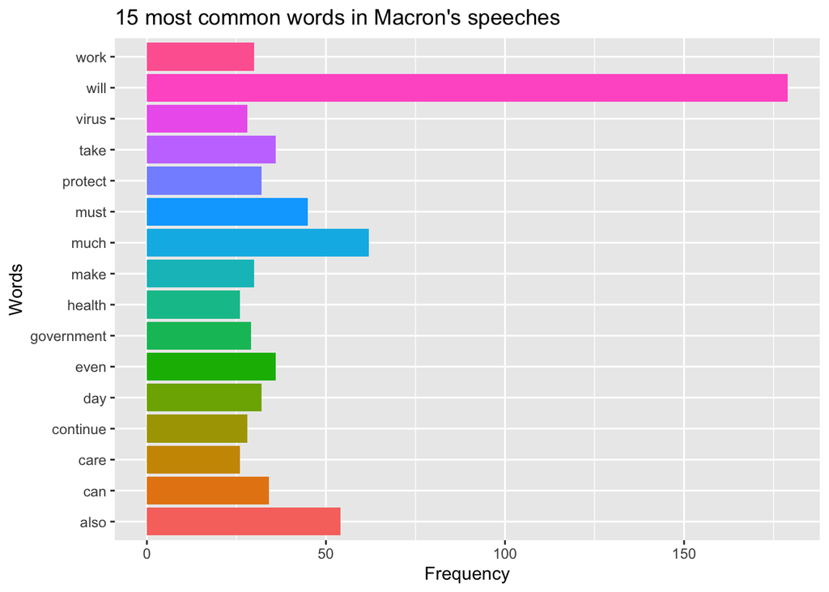

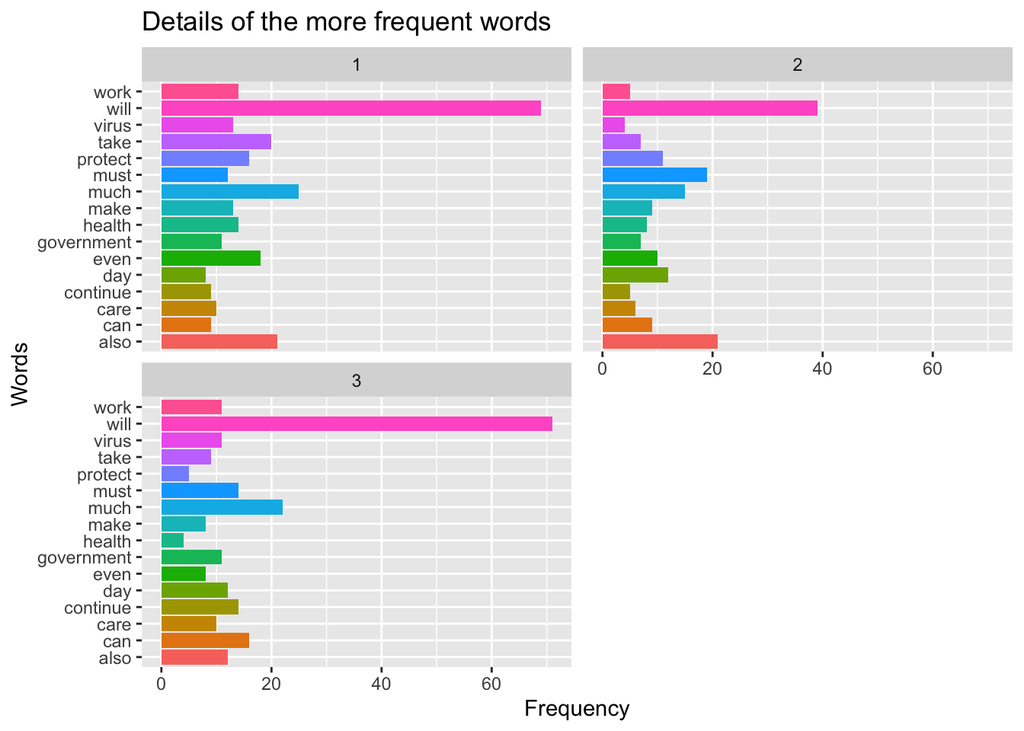

*Boris Johnson*

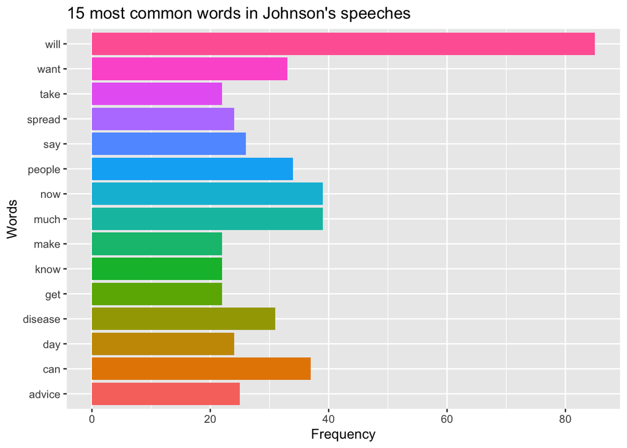

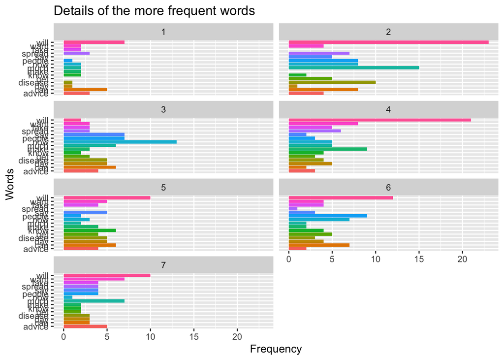

We see that the list of 15 most frequent term are due to doc 2 ,4 and 3.

#### Per text

Now we want to know which are the most frequent term for each speach.

*Emmanuel Macron*

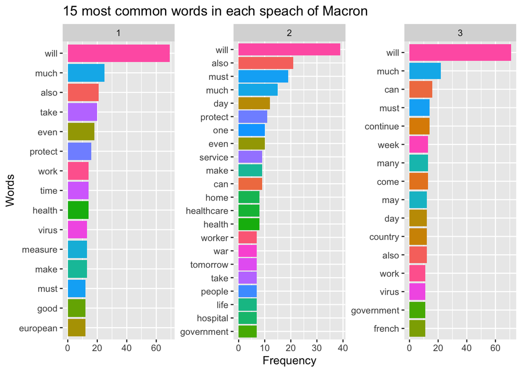

*Boris Johnson*

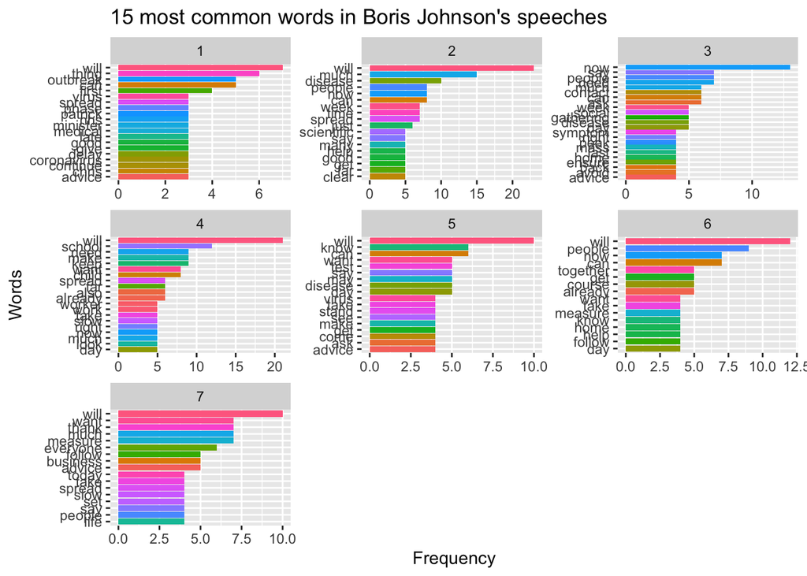

## TF-IDF

Now we repeat the same analysis using the TF-IDF.

### Emmanuel Macron

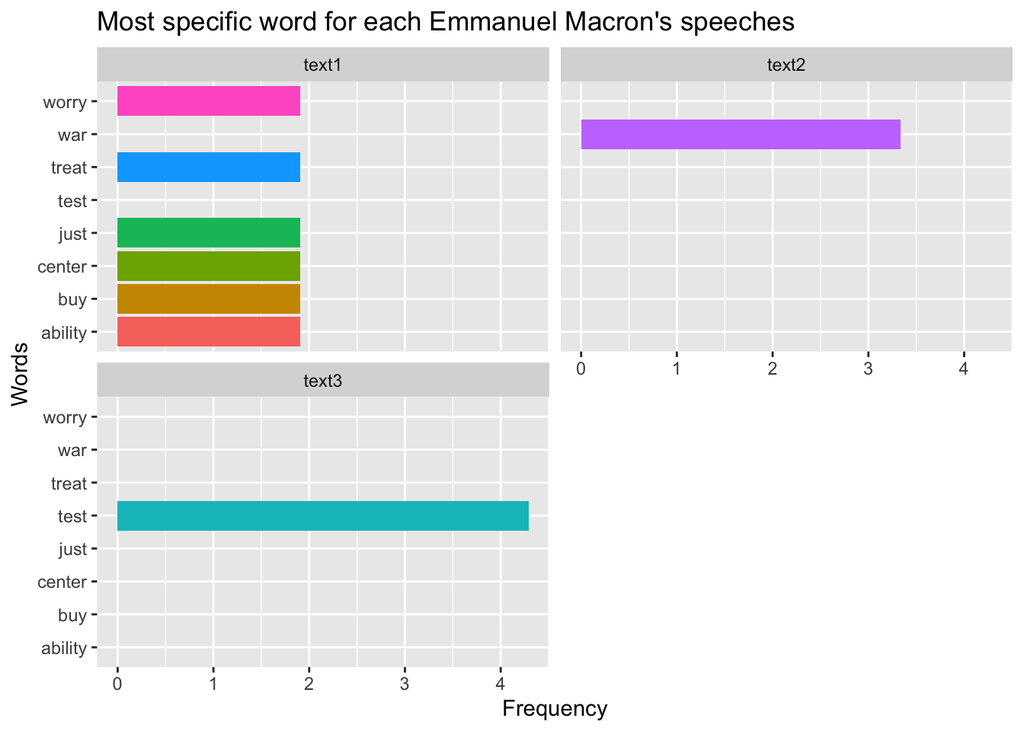

### Boris Johnson

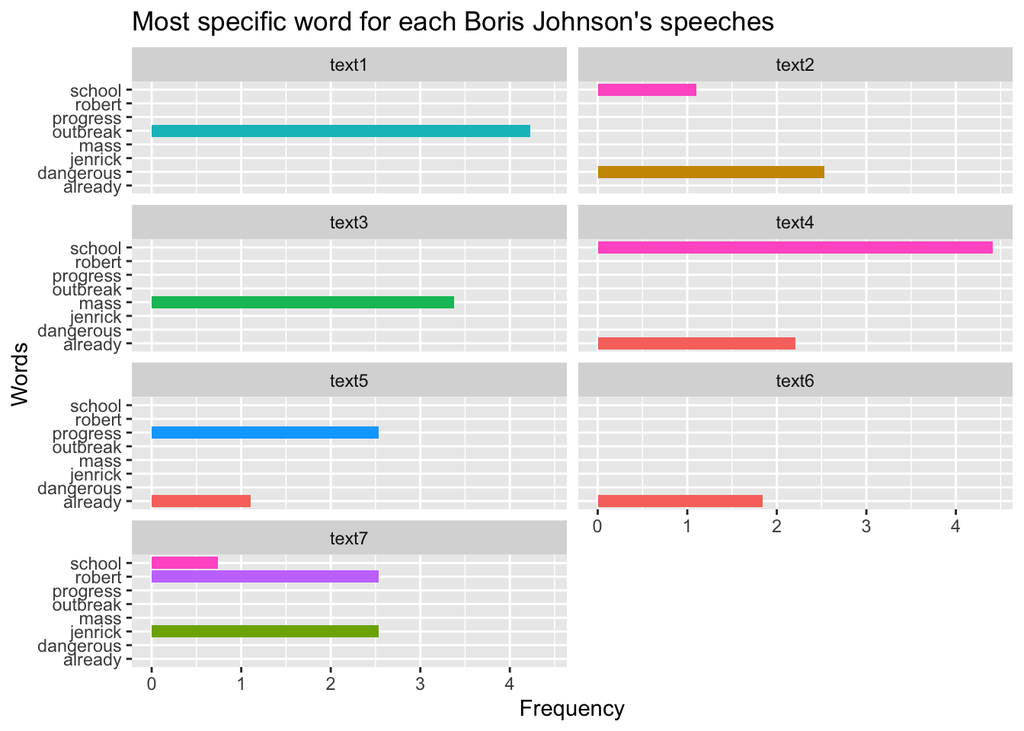

## Cloud of Words

### Usind DFM

*Emmanuel macron*

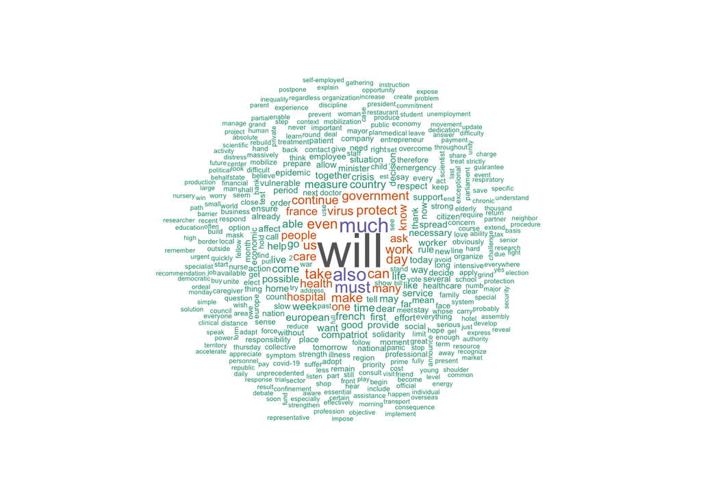

*Boris Johnson*

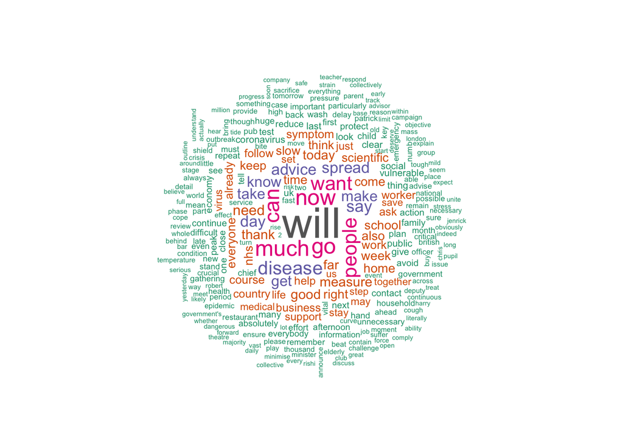

### Using TF-IDF

*Emmanuel macron*

[figure not shown]

*Boris Johnson*

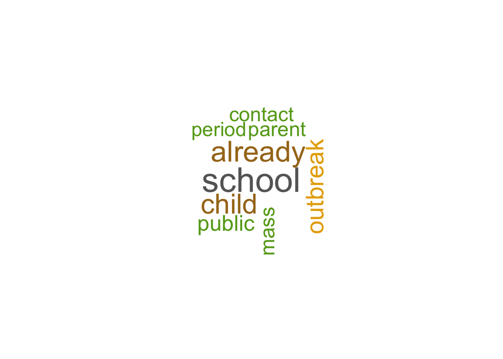

## Lexical Divesity Token Type Ratio TTR

A TTR is comprised beetween o and 1.When equal to 1 it correspond to a rich diversity, every token is from a different type. In opposit if equal to 0, it mean a poor diversity ( he use only one word).

### Emmanuel Macron

Lexical diversity of Macron.

|  | x |
| --- | --- |
| text1 | 0.4127 |
| text2 | 0.4932 |
| text3 | 0.4888 |

Lexical diversity of Johnson.

|  | x |
| --- | --- |
| text1 | 0.6744 |
| text2 | 0.5478 |
| text3 | 0.5583 |
| text4 | 0.5092 |
| text5 | 0.5761 |
| text6 | 0.6114 |
| text7 | 0.6113 |

Now, we illustrate the Zipf’s law on the discours. The terms are ranked by their frequency (rank=1 for the most frequent), then plotted versus its rank. This is easily obtained using quanteda.

### Emmanuel Macron

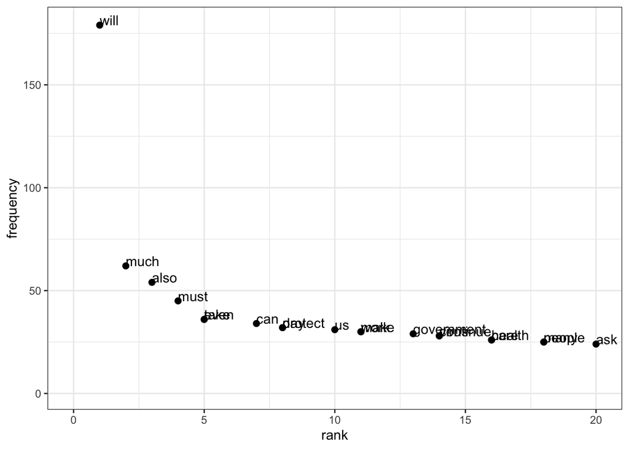

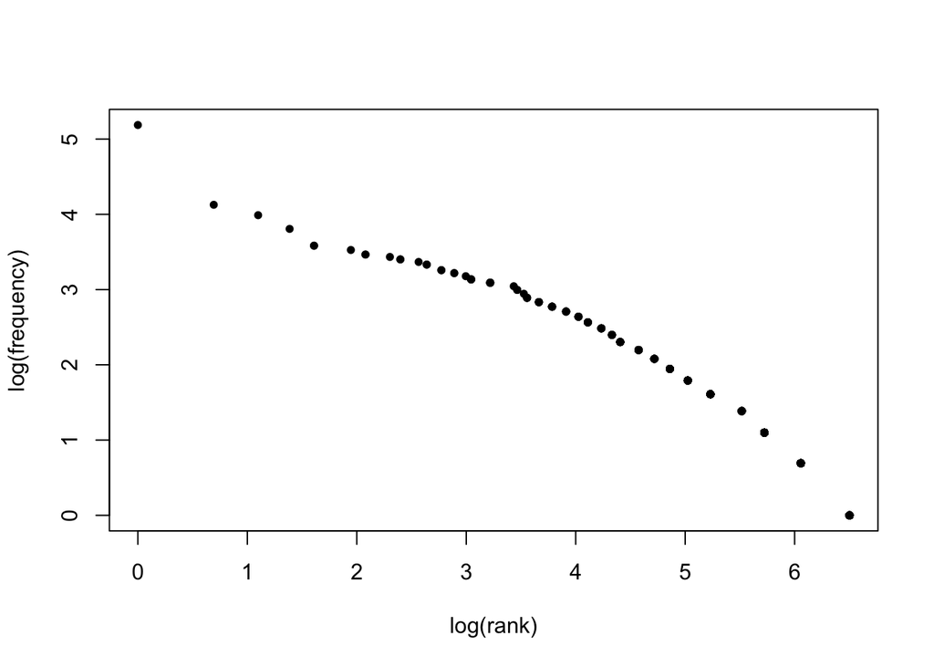

### Boris Johnson

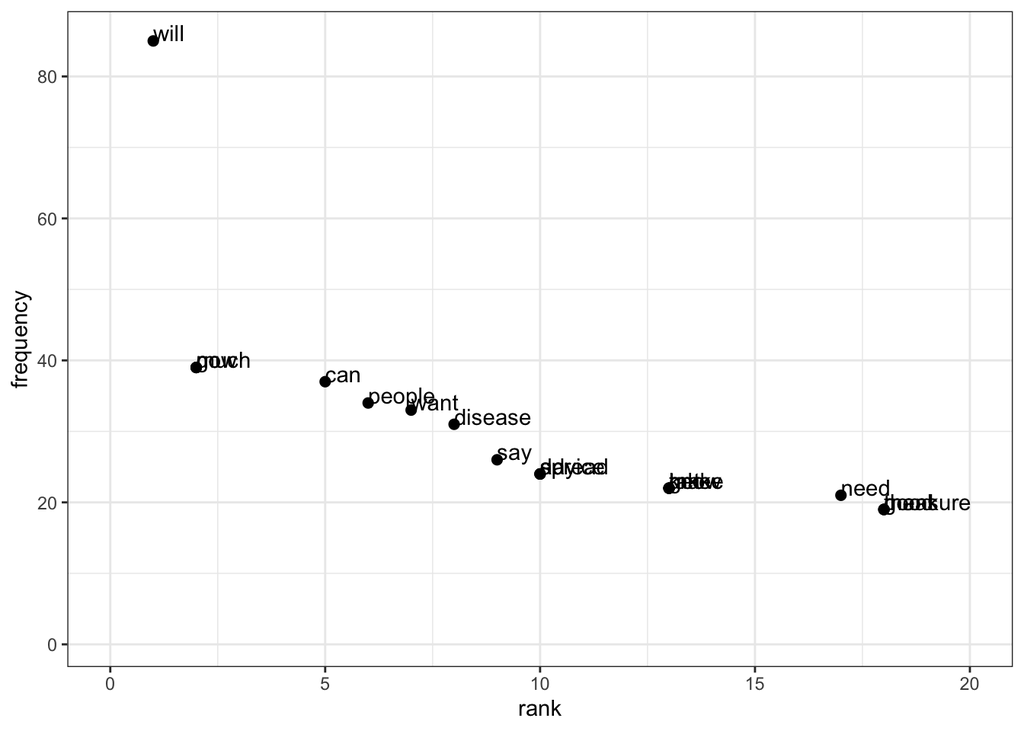

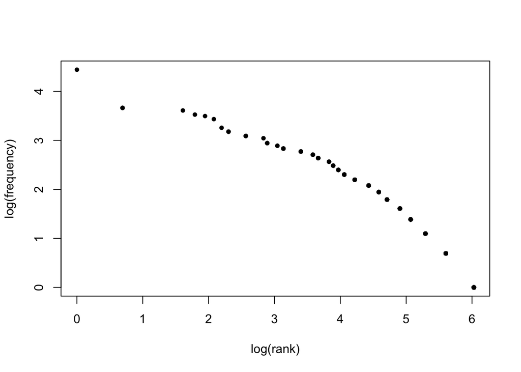

## Yule’s index

A larger index mean more diversity.

### Emmanuel Macron

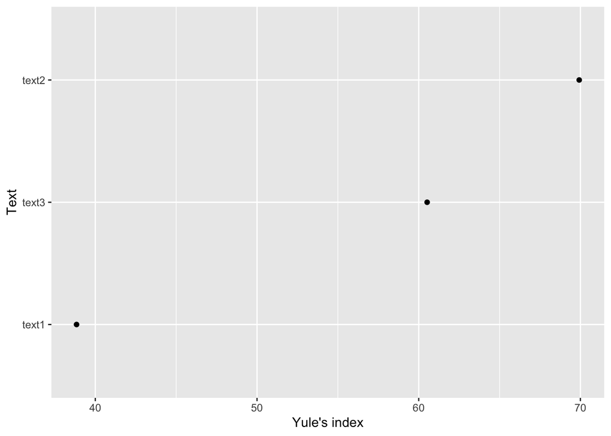

### Boris Johnson

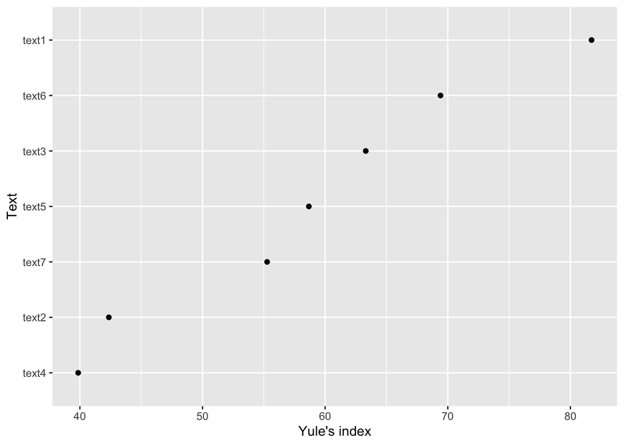

## MATTR

It is the Moving Average Type-Token Ratio

### Emmanuel Macron

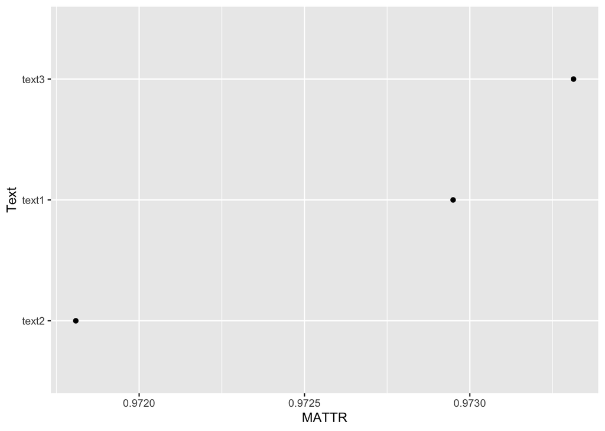

### Boris Johnson

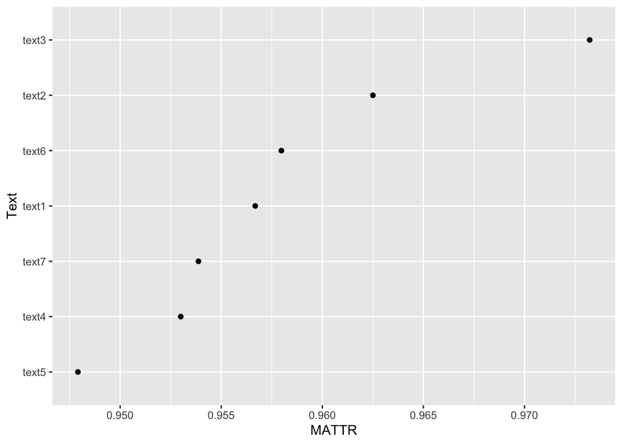